# A Pipeline for Agile Estimation of Land Accounts (PAELA)

Component 2 - V2.2

Christophe Bontemps (SIAP) - Blanca Perez Lapena (ESCAP)

08 May, 2025

# Foreword

This is the second component of the **P**ipeline for **A**gile **E**stimation of **L**and **A**ccounts (PAELA project). The first component aims at acquiring two types of information:

- Satellite information for a specified year covering the study area.
- Regions of Interest (ROIs) with different land cover classes that will serve as “ground truth” references for a Machine Learning model to learn how to relate satellite pixels with on the ground classifications.

This **second** component will use the ROIs from the first component and a newly created stacked image (individual bands and spectral indices) as inputs to train a Machine Learning model. This component will provide a ready-to-use, fully trained model for classifying land types. It follows an agile programming framework structured in separate, individual chunks fully adjustable and reproducible. Also, this component will apply the trained model to estimate land cover types for the entire study area using the stacked image.

The **third** component will then refine the land cover maps (from the second component), including an analysis of improbable land cover transitions over the accounting period, for Land Account compilation in the **fourth** component.

# Training the machine Learning Model

### Packages needed for training a Machine learning model

As usual when working with specific data, We need both generic and specific packages. We have 3 broad categories:

- Packages specific to GIS and maps such as `sf` and `raster`
- Packages specific to Data Science and Machine Learning, in particular the package `CARET` that embeds many models and post-estimation features and graphics
- Generic packages for data management, visualization and dissemination such as `dplyr` and `ggplot2`.

```r
# GIS packages
library(raster) ## for reading "RASTER" files
library(sf)     ## read shapefiles
library(sp)     ## for adjusting CRS in
library(terra)  ## see https://www.neonscience.org/resources/learning-hub/tutorials/image-raster-data-r

# Model fitting packages for ML
library(rpart)
library(caret)

# File management
library(readxl)
# Tidy data management packages
library(dplyr)
library(data.table)
library(modelsummary)
library(ggcorrplot)
library(forcats)

# Plotting packages
library(ggplot2)
library(RColorBrewer)
library("patchwork") # To combine plots

# Nice presentation of results
library(knitr)
library(papeR)

# My colors:
SIAP.color <- "#0385a8"
SIAP.red <- "#eb4034"
```

# Data and files management

Firstly, we must define the year under study. We’ll put that into parameters that will be used now consistently over the whole program.

```r
MyDir <- "GIS-ROI-V2"
StudyYear  <- 2023
```

> The year under study is **2023**

We will import and export files in different format, including GIS specific files in formats that can be *raster* (images) or *shapefiles* (vectors). Also, we will need to combine, assemble and transform these files to use them as data frames for the Machine Learning model.

> Important, when changing year: Clear the cache (remove files on the hard disk).

## Importing geospatial information

There are many data sources freely available with environmental information at a very detailed level. These files are from huge data bases that cover large areas of the word.

## a. Importing the stack of images (TIFF)

From QGIS, we import the images that corresponds to the island of Efate.

```r
# import stacked raster (TIFF images)
# Needs  sf package

img <- brick(paste0("Data/",MyDir,"/stacked_image_",StudyYear,"_20m.tif"))
```

These are images taken with different bands and reflecting the nature of waves coming back from the satellite sensors. These will be our predictors, or explanatory variables, for our model, as the information is available for any point on the region.

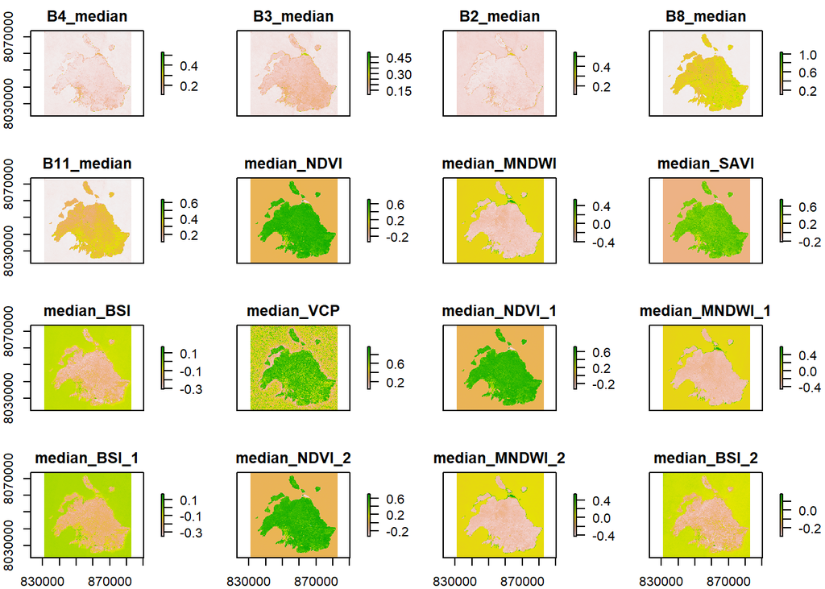

```r
plot(img)
```

## b. *ROIs* or “*ground truth*” land classes (shapefiles)

The Region of Interest or **ROIs** are also called “*ground truth*” areas where we *know* or *observed* the nature of the the land and its class. This is a limited sample and this sample is important for training our model and for validating the model trained and compute its accuracy on a validation sub sample. So that sample will define the set of points where the information is available. Here it comes directly from QGIS as a shapefile (*.shp*).

> See componenet 1 (Blanca) for more explanation on the construction of the ROIs

```r
# Importing ROIs (Shapefiles)

shp <- read_sf(paste0("Data/",MyDir,"/ROI",StudyYear,"/"))
```

One can check the classes tat have beeen defined in the shapefile and their labels.

```r
# table of classes, as defined in the shp file

ClassesRaw <- as.data.frame(shp) %>%
  group_by(MC_ID, MC_name) %>%
  count() %>%
  arrange(desc(n))

kable(ClassesRaw)
# Class 3 does not exist! And cloud is NA!
```

[output not shown]

Here, we have 12 classes but some may have wrong labels or simply ot existing.

```r
shp <-shp %>%
  mutate(MC_name = ifelse(MC_ID ==12, "Cloud", MC_name))
```

```r
# extract classes and band information and put in a dataframe for later
names(img) <- c("4_red", "3_green", "2_blue", "8_nir", "11_swir16", "y_ndvi", "y_mndwi", "y_savi", "y_bsi", "y_vcp", "dry_ndvi", "dry_mndwi","dry_bsi","wet_ndvi","wet_mndwi","wet_bsi")
```

## c. Matching class values (ROIs) with the information from Raster (bands)

We can now match the information from the ground truth, with what is available from the images (raster). This operation, that uses the exact location and a perfect geographical alignment, will provide a sample with both the information of the nature of the land (in classes)and the information from the satellite (predictors).

```r
# Matching the ROIs with the stack of images (bands) to create a data frame
DataForModel <- terra::extract(img, shp, df = TRUE)
```

```r
# Assigning class for each location
DataForModel$class <- as.factor(shp$MC_ID[match(DataForModel$ID, seq(nrow(shp)))])

DataForModel$class <- factor(DataForModel$class)
```

> It can be useful to label the 12 land classes for a better interpretation and visualization. This can be a bit tricky if one value (and one label ) is not observed.

```r
# Saving the Dataset for Modeling as a csv file to avoid rerunning these lengthy steps
save(DataForModel, file = paste0("Data/",MyDir,"/DataForModel.Rda"))

# Uncomment to load the data
# load("Data/GIS-ROI-V1/DataForModel.Rda")
```

## Summary statistics

Let’s have a look at the sample created with **15965** observations:

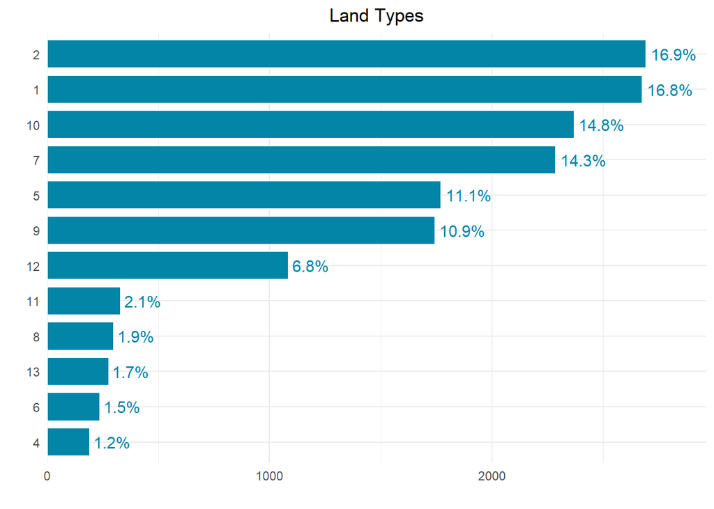

```r
DataForModel %>%
  # Reorder and reverse factor levels
  mutate(class = fct_infreq(class) %>% fct_rev()) %>%
  # Calculate percentages
  count(class, name = "count") %>%
  mutate(percentage = round(100 * count / sum(count), 1)) %>% # Calculate percentages
  ggplot(aes(x = count, y = class)) +  # Use x = count for horizontal bar lengths
  geom_bar(stat = "identity", fill = SIAP.color, colour = "white", width = 0.8) +
  # Add percentages
  geom_text(aes(x = count, label = paste0(percentage, "%")), hjust = -0.1, color = SIAP.color, size = 4) +
  scale_x_continuous(expand = expansion(mult = c(0, 0.1))) +  # Extend the x-axis for labels
  theme_minimal() +
  theme(plot.title = element_text(hjust = 0.5)) +
  labs(x = "", y = "") +
  ggtitle("Land Types")
```

> There is a **class imbalance** in the explanatory variable `class`, with classes *Forest (open or dense)* and *Other vegetation* being more numerous than other classes. We need to **keep this in mind** as this may affect the machine Learning model.

## Predictors

The list of explanatory variables (or *predictors*) are the different bands from the satellite images. For each location, we have a value from each band stored in a variable.

[1] “X4_red” “X3_green” “X2_blue” “X8_nir” “X11_swir16” [6] “y_ndvi” “y_mndwi” “y_savi” “y_bsi” “y_vcp”  
[11] “dry_ndvi” “dry_mndwi” “dry_bsi” “wet_ndvi” “wet_mndwi” [16] “wet_bsi”

> In total with have **16** predictors.

```r
datasummary_skim(select(DataForModel, predictor_vars) ,   type = "numeric",
                 title = "Full data set (DataForModel)",
                notes = paste("N =", nrow(DataForModel)) )
```

Unique

Missing Pct.

Mean

SD

Min

Median

Max

Histogram

X4_red

4816

0

0.1

0.0

0.1

0.1

0.7

[figure not shown]

X3_green

5138

0

0.2

0.0

0.1

0.2

0.7

[figure not shown]

X2_blue

4425

0

0.1

0.0

0.1

0.1

0.7

[figure not shown]

X8_nir

7879

0

0.5

0.2

0.1

0.5

1.0

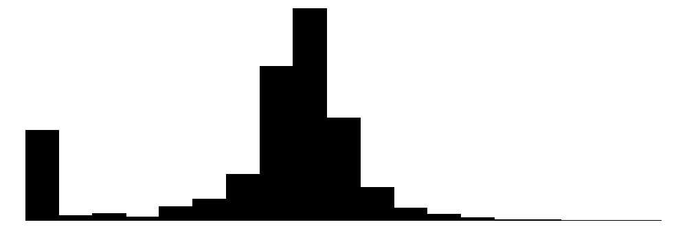

X11_swir16

6403

0

0.3

0.1

0.1

0.3

0.7

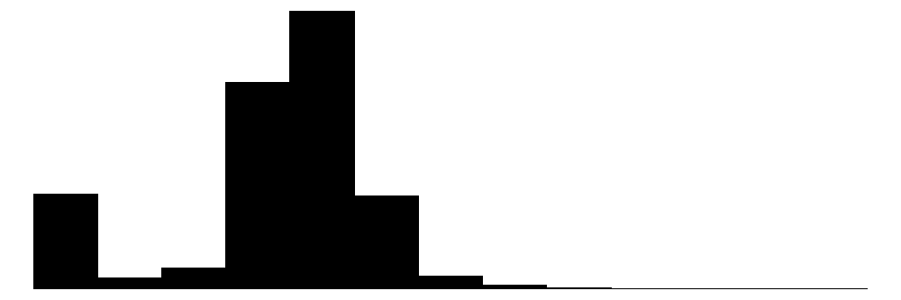

y_ndvi

15891

0

0.5

0.2

-0.4

0.6

0.7

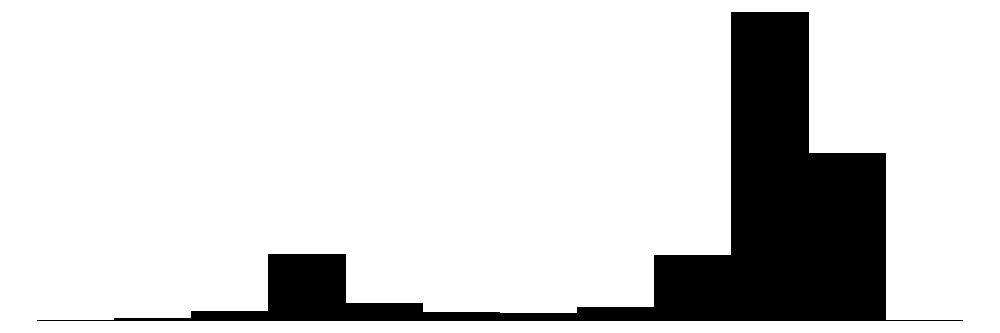

y_mndwi

15863

0

-0.2

0.1

-0.5

-0.3

0.6

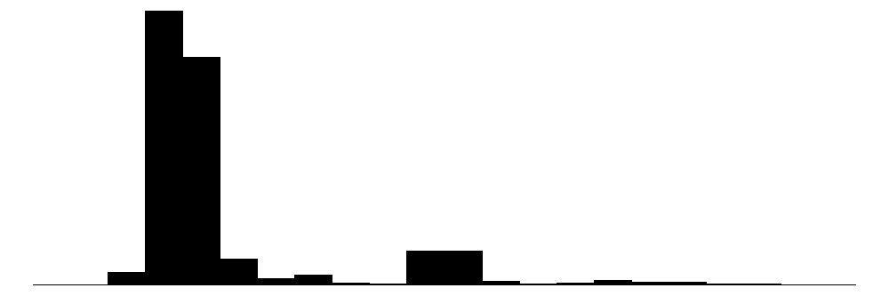

y_savi

15885

0

0.4

0.2

-0.2

0.5

0.7

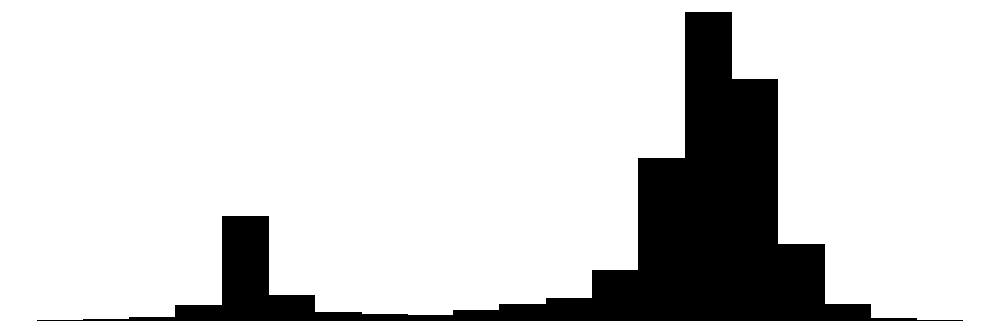

y_bsi

15910

0

-0.2

0.1

-0.3

-0.2

0.2

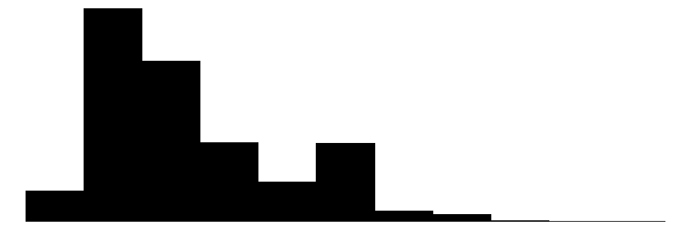

y_vcp

15912

0

0.7

0.2

0.1

0.7

1.0

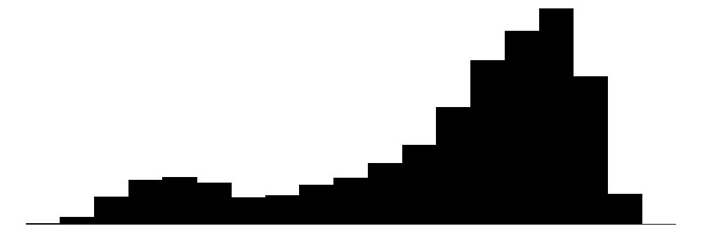

dry_ndvi

15827

0

0.5

0.2

-0.4

0.6

0.7

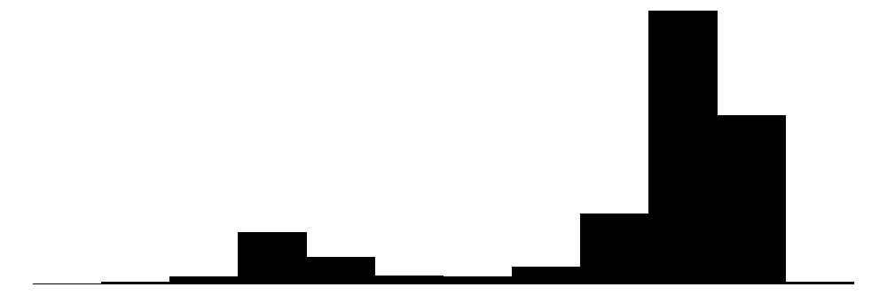

dry_mndwi

15806

0

-0.2

0.2

-0.5

-0.3

0.6

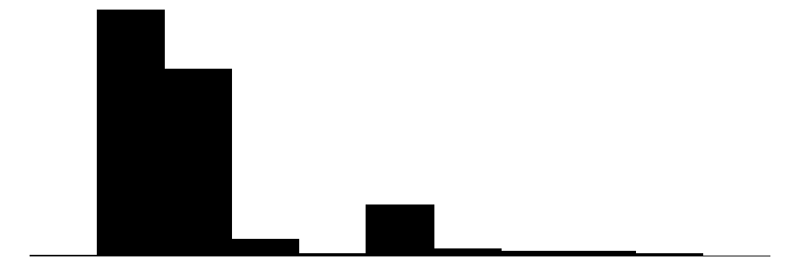

dry_bsi

15889

0

-0.2

0.1

-0.3

-0.2

0.2

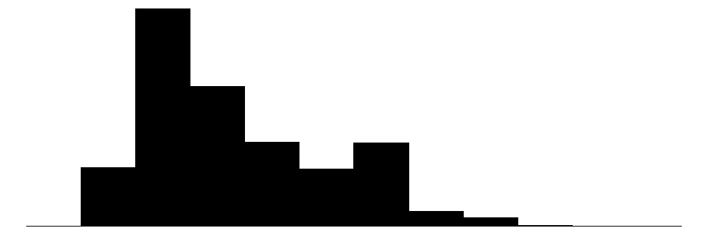

wet_ndvi

15857

0

0.5

0.2

-0.4

0.6

0.7

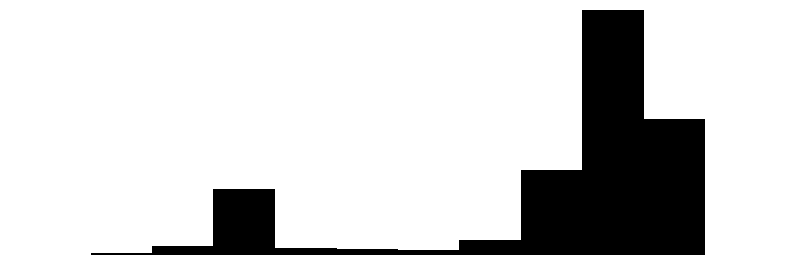

wet_mndwi

15833

0

-0.2

0.1

-0.5

-0.3

0.6

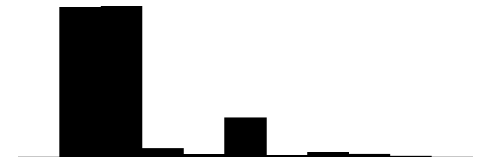

wet_bsi

15911

0

-0.2

0.1

-0.3

-0.2

0.2

[figure not shown]

# Explanatory variables analysis

It is always a good thing to explore the variables that we are going to use as predictor and try to find variables that are related to each other. Here the bands are not really easy to interpret but we can still see some patterns.

More importantly, we may identify groups of variables that are correlated, as well as the variables that are not correlated with any other. Those could capture unique features of the images having nice predicting power.

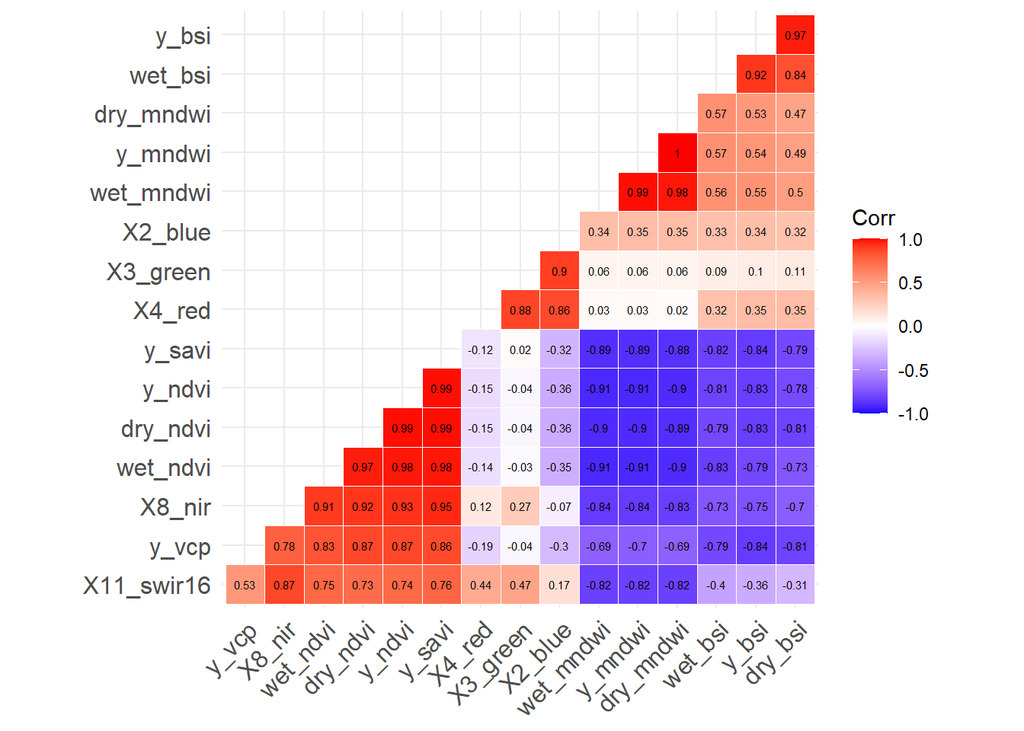

```r
# We compute the correlation matrix of the covariates
corr_coef<-cor(DataForModel[, predictor_vars], use = "p")

#And then plot it with nice options
ggcorrplot(corr_coef,
           type = "lower",         # lower triangle of the matrix only
           hc.order = TRUE,        # variable sorted from highest to lowest
           outline.col = "white",  #Color options
           lab = TRUE,
           lab_size = 2)
```

The data preparation & validation methods ends here, so let’s process to machine learning models.

# Machine learning

As usual in Machine Learning, we need to divide the original sample with 15965 into *training* and *validation* samples based on a 80-20% rule. This has to be done randomly to avoid any pattern to be appearing in only one of the two samples that should have the same characteristics.

## Train and Validation data sets

```r
# Splits data into training and testing sets
set.seed(007)  # Seed for splitting train/validation sets

# We randomly pick observations (indexes) from the full data set
trainIndex <- createDataPartition(DataForModel$class, p = .80,
                                  list = FALSE,
                                  times = 1)

# Creating the two data sets by partition
train_data <- DataForModel[ trainIndex,]
validation_data  <- DataForModel[-trainIndex,]
```

We have 12776 observations in the training data set (80%) and 3189 observations in the validation data set (20%). It is important to have a look at our train data set and check if it has the same characteristics, in particular for the categories distribution.

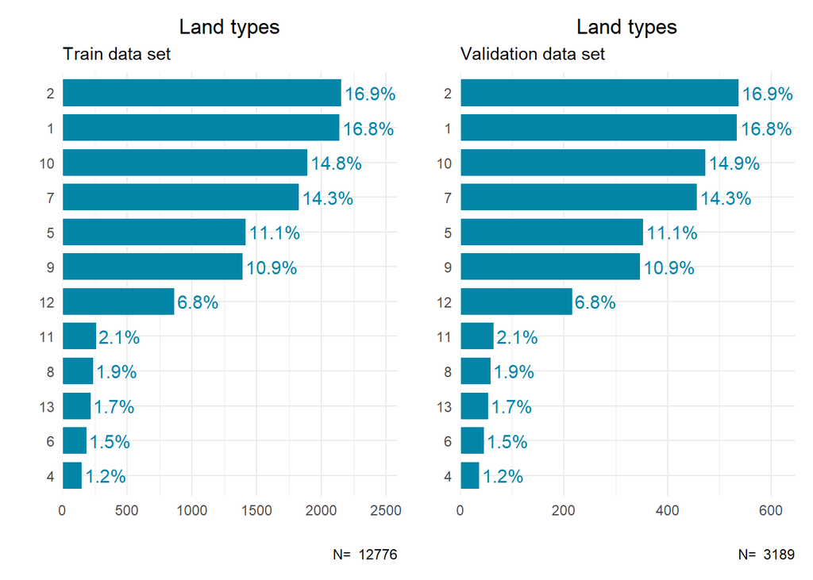

## Missing values in the training and validation data sets

After creating the two sub-samples, it is good to check whether the process worked well and has not created any missing observation (that may happen!).

```r
# Checking missing values see https://rpubs.com/NguyenKhanh20/1069336

mis_train <- sum(is.na(train_data))
mis_train_obs  <- nrow(train_data[!complete.cases(train_data), ])

mis_valid <- sum(is.na(validation_data))
mis_valid_obs  <- nrow(validation_data[!complete.cases(validation_data), ])
```

We have **0 missing values** in the training data set (any variables) and **0** missing values for the validation data set. This concerns **0** observation(s) in the training data set and **0** observation(s) in the validation data set. If we observe some missing, we should remove these observations to have non missing training and validation data sets.

```r
# removing the missing observation from training data set
train_data <- train_data[complete.cases(train_data), ]
validation_data <- validation_data[complete.cases(validation_data), ]
```

## Selecting Cross Validation parameters

```r
# control variables (see later)
K <- 5        # K for K-fold Cross-Validation
Myrepeats <- 10
rcvTunes <- 1  # tune number of models
Myseed <- 2512 # Seed for ML training
```

## Random Forest

We begin with fitting a Random Forest model using cross-validation on the *Training* data set

Random Forest is a *bagging* (*bootstrap aggregation*) method. During training a bootstrap sample is drawn from the training data together with a subset of the total amount of variables, we then pick the best available variable to split the tree into two daughter nodes repeatedly until we reach a stopping criterion. This process is repeated until we have trained as many individual decision trees as we want. We can then combine the output of the decision trees into one final output.

Our final output will be based on the **majority vote** of the individual decision trees.

### Training the model on selected variables

We can decide to train the model on all the explanatory variables (using `.` as right-hand side of the formula as below) or an only a subset of the variables that are available to us:

- So using all variables would write `rf_fit <- train(class ~ . , ...`
- Alternatively, we could use a `formula` and write `rf_fit <- train(formula, ...`

For more flexibility, we use that second option here:

```r
# The formula definition with defined predictors
formula <- as.formula(paste("class ~", paste(predictor_vars, collapse = " + ")))
```

> Our `formula` with **16 predictors** ( or explanatory variables, “*bands* here) is:

> class ~ X4_red + X3_green + X2_blue + X8_nir + X11_swir16 + y_ndvi + y_mndwi + y_savi + y_bsi + y_vcp + dry_ndvi + dry_mndwi + dry_bsi + wet_ndvi + wet_mndwi + wet_bsi

And we can train our model:

```r
# Train your model using the subset of variables
rf_fit <- train(formula,
                data = train_data,
                method = "rf",
                ntree = 100,
                trControl = K5_CV_seed)
```

```r
rf_fit
```

```
## Random Forest
##
## 12776 samples
##    16 predictor
##    12 classes: '1', '10', '11', '12', '13', '2', '4', '5', '6', '7', '8', '9'
##
## No pre-processing
## Resampling: Cross-Validated (5 fold)
## Summary of sample sizes: 10222, 10221, 10221, 10220, 10220
## Resampling results across tuning parameters:
##
##   mtry  Accuracy   Kappa
##    2    0.8132440  0.7852675
##    9    0.8172354  0.7898681
##   16    0.8145747  0.7867781
##
## Accuracy was used to select the optimal model using the largest value.
## The final value used for the model was mtry = 9.
```

By default, `caret` does a minimal search on the number of variables used for each node of each tree, `mtry`. While training the model, `caret` searched for 3 values of `mtry`, here (all) and provides the value of the accuracy and Kappa for each of these choices. By default, it will the select the value that maximize the accuracy. Obviously, we can also try to optimize this choice and do our own selection.

## Playing with parameters for the RF model

The package `caret` allows a lot of testing for the “right” choice of parameters affecting random forest models. In particular `mtry` and `ntree`. Let us change these parameters and see how this affects our model accuracy

### The number of variables used for each node of each tree `mtry`

By default, `caret`does a minimal search of 3 different numbers for `mtry` and selects the one that maximize accuracy. Let’s change that parameter to do an extensive **grid search** up to the maximum possible.

```r
rf_fit <- train(formula,
                data = train_data,
                method = "rf",
                ntree = 100,
                tuneLength = 16, #  <- computes for 16 values of mtry
                metric= "Kappa",  # we can choose the criteria (Kappa vs Accuracy)
                trControl = K5_CV_seed)
```

```r
rf_fit
```

```
## Random Forest
##
## 12776 samples
##    16 predictor
##    12 classes: '1', '10', '11', '12', '13', '2', '4', '5', '6', '7', '8', '9'
##
## No pre-processing
## Resampling: Cross-Validated (5 fold)
## Summary of sample sizes: 10220, 10223, 10221, 10220, 10220
## Resampling results across tuning parameters:
##
##   mtry  Accuracy   Kappa
##    2    0.8130884  0.7850913
##    3    0.8206023  0.7937347
##    4    0.8204460  0.7935638
##    5    0.8203663  0.7934796
##    6    0.8220891  0.7954827
##    7    0.8209937  0.7942152
##    8    0.8186448  0.7915239
##    9    0.8211511  0.7943973
##   10    0.8198190  0.7928695
##   11    0.8194289  0.7924233
##   12    0.8183318  0.7911442
##   13    0.8189585  0.7918471
##   14    0.8162192  0.7887170
##   15    0.8193499  0.7923179
##   16    0.8141829  0.7863852
##
## Kappa was used to select the optimal model using the largest value.
## The final value used for the model was mtry = 6.
```

```r
# Sececting the "Best" number of trees
mtry_best <- rf_fit$bestTune[[1]]
```

The results, in terms of accuracy (or *Kappa*) can be visualized to identify the best value for the number of regressors per `mtry` leading to the highest accuracy.

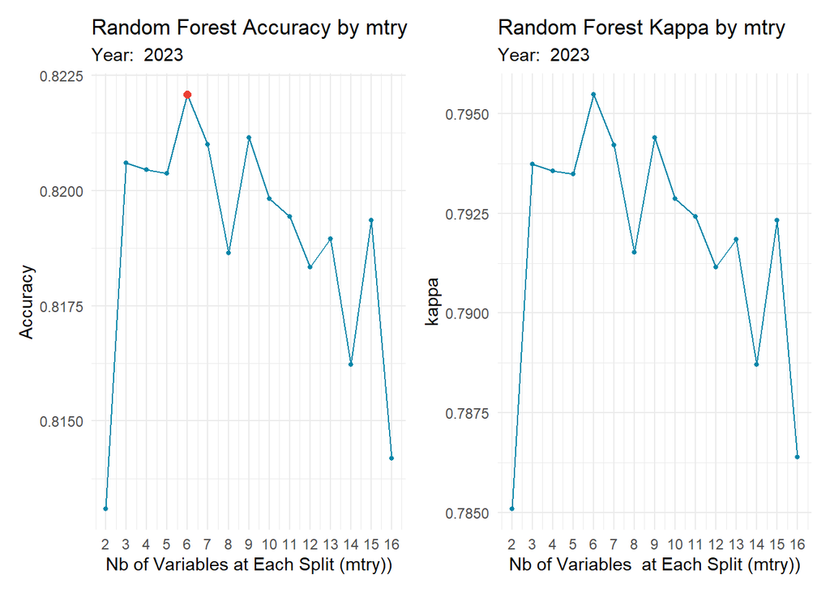

```r
# Getting the results
rf_results <- rf_fit$results

# Plot of accuracy
p_A <- ggplot(rf_results, aes(x = mtry, y = Accuracy)) +
  geom_line(color = SIAP.color) +
  geom_point(size = 1, color = SIAP.color) +
  # Highlight the optimal point
  geom_point(data = rf_results %>% filter(mtry == mtry_best),
             aes(x = mtry, y = Accuracy),
             color = SIAP.red, size = 2) +
  scale_x_continuous(breaks = seq(min(rf_results$mtry), max(rf_results$mtry), by = 1)) +
  labs(
    title = "Random Forest Accuracy by mtry",
    subtitle = paste("Year: ", StudyYear,""),
    x = "Nb of Variables at Each Split (mtry))",
    y = "Accuracy"
  ) +
  theme_minimal()

# Plot of Kappa
p_K <- ggplot(rf_results, aes(x = mtry, y = Kappa)) +
  geom_line(color = SIAP.color) +
  geom_point(size = 1, color = SIAP.color) +
  scale_x_continuous(breaks = seq(min(rf_results$mtry), max(rf_results$mtry), by = 1)) +
  labs(
    title = "Random Forest Kappa by mtry",
    subtitle = paste("Year: ", StudyYear),
    x = "Nb of Variables  at Each Split (mtry))",
    y = "kappa"
  ) +
  theme_minimal()

# Combine the plots
p_A |  p_K
```

From these graphics, we can conclude that the we should select **6 regressors** per trees in the random forest model, and then set the `mtry` parameter accordingly (to 6).

### The number of trees used `ntree`

Even better, we can combine the search of `ntree` with the search if `mtry` using a grid search. Since we know that our best choice for `mtry` was to use only 6 regressors per trees in the random forest, we can impose that choice in our grid.

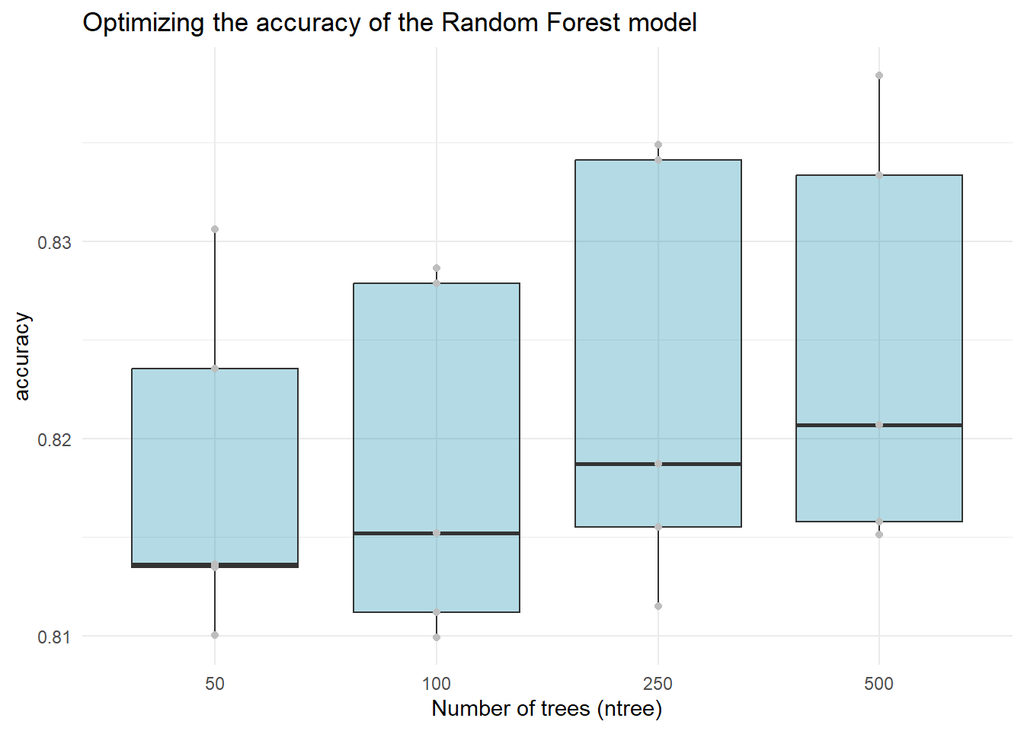

We now know that the optimal number of trees seems to be `ntree` = **500**. This result, combined with the the optimal number of predictors *per* tree (set to `mtry` = 6) allows us to **fine-tune** our machine learning model. `

### Final model selection

Based on what we have discovered, it seems that selecting a Random Forest model with **`ntree` = 500**, **`mtry` = 6** should be a quite good option. Since we have quite imbalance classes, we also will rely more on the value of the *kappa* parameter that in the pure accuracy in the remaining part of the analysis.

```r
# Uses the optimal mtry from the previous model
grid <- expand.grid(.mtry=  mtry_best) # <- this is the way to impose mtry*

# Solution automatically picked
# ntree = ntree_best
ntree = 250  ## <- My Choice
```

> One can still decide manually to select the parameters, and here **I** have decided to select “*only*” **250 trees** for the analysis.

```r
#Train a model  with fixed mtry and ntree parameters, other parameters are as previously defined
rf_final_fit <- train(formula,
                data = train_data,
                method = "rf",
                metric = 'kappa',
                tuneGrid = grid,
                trControl = K5_CV_seed,
                ntree = ntree)

rf_final_fit
```

## Evaluating Model Performance

We can assess the quality of the model both *in sample*, that is how well the model estimates the data within the training data set or *out of sample* , where we compare predictions based on a validation data set (or “*unseen data*”). The results with both samples are interesting and should provide us with different information on the quality of the training and on the performance of the trained model on new, unseen, data sets.

### *In sample* performance

We can assess the performance of the trained model by its ability to predict in sample, that is predicting within the data set used for training. Obviously the results should be *quite good* as the model uses the same data for predicting and estimating.

The overall **in-sample** performance is:

```
##  Accuracy     Kappa
## 0.9996086 0.9995505
```

we have an accuracy of **99.96** % while the confusion matrix is:

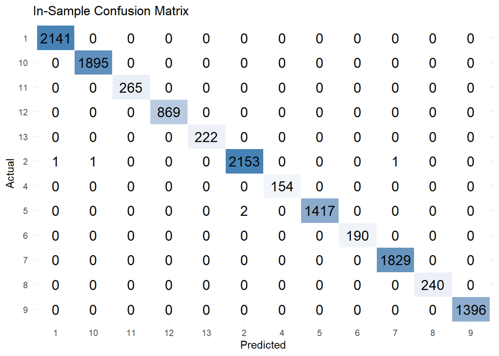

```r
# c_in$table

# Convert the confusion matrix to a data frame
cm_in_df <- as.data.frame(c_in$table)


# Plot with reversed Y-axis and added total column
cm_in_df %>%
  ggplot(aes(x = Reference, y = fct_rev(Prediction), fill = Freq)) +
  geom_tile(color = "white") +
  geom_text(aes(label = Freq), color = "black", size = 5) +
  scale_fill_gradient(low = "white", high = "steelblue") +
  labs(title = "In-Sample Confusion Matrix", x = "Predicted", y = "Actual") +
  theme_minimal()+
  theme (legend.position ="none")
```

We need now further investigation to see if the model generalizes well or if it just has learned from the training data. A high accuracy is generally a symptom of *overfitting* and of possible poor performance on the validation sample.

### Variable importance

We can check which of the predictors had an influence in the classification by using the Variable Influence Factor (VIF) on a graphic:

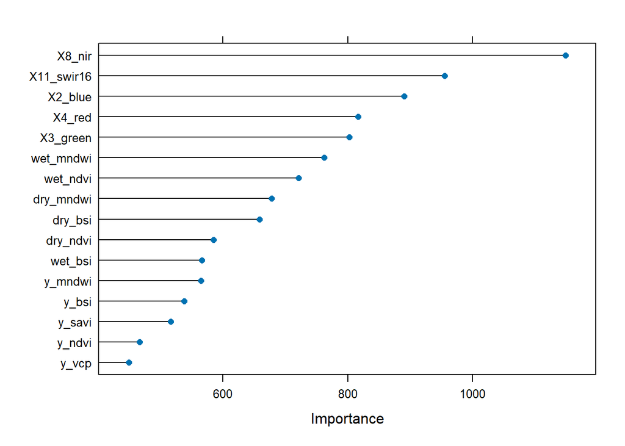

```r
GISVarImportance<- varImp(rf_final_fit, scale = FALSE)
plot(GISVarImportance, title =" VIF (final model)")
```

### The *out-of-sample* performance

We now apply the model to the validation sample, that has not been used for training the model. This is where we will truly see the prediction performances of the model by comparing the predictions with actual real values (or reference in the confusion matrix below.

```r
rf_pred_Valid <- predict(rf_final_fit, validation_data)
rf_CM <- confusionMatrix(rf_pred_Valid, validation_data$class)
# rf_CM$table
```

```r
# Out-of-sample accuracy
outsample_accuracy <- round(100*rf_CM$overall[1], 2)
```

On the *validation set*, with 3189 points, we have an accuracy of **83.47** %.

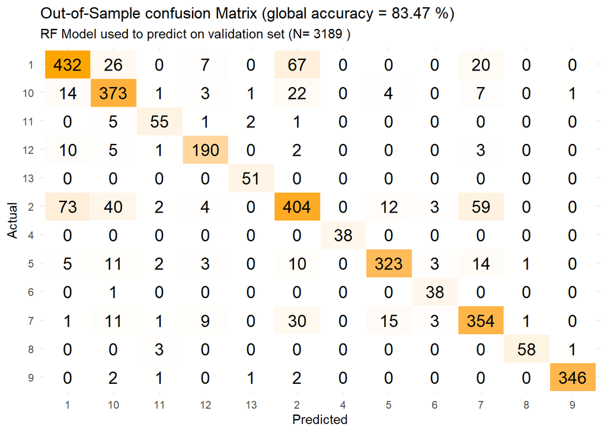

```r
# Convert the confusion matrix to a data frame
cm_df <- as.data.frame(rf_CM$table)
# Plot with reversed Y-axis and added total column
cm_df %>%
  ggplot(aes(x = Reference, y = fct_rev(Prediction), fill = Freq)) +
  geom_tile(color = "white") +
  geom_text(aes(label = Freq), color = "black", size = 5) +
  scale_fill_gradient(low = "white", high = "orange") +
  labs(title = paste("Out-of-Sample confusion Matrix (global accuracy =",outsample_accuracy, "%)"),
       subtitle = paste("RF Model used to predict on validation set (N=",nrow(validation_data), ")"),
       x = "Predicted", y = "Actual") +
  theme_minimal()+
  theme (legend.position ="none")
```

### Predicted classification on the validation sample

Our validation sample has **3189** observations. Let’s see how the prediction goes on the different land classes.

```r
pred_classes_RF <- pred_valid %>%
  mutate(class = as.factor(rf_pred_Valid)) %>%
  group_by(class) %>%
  count()
```

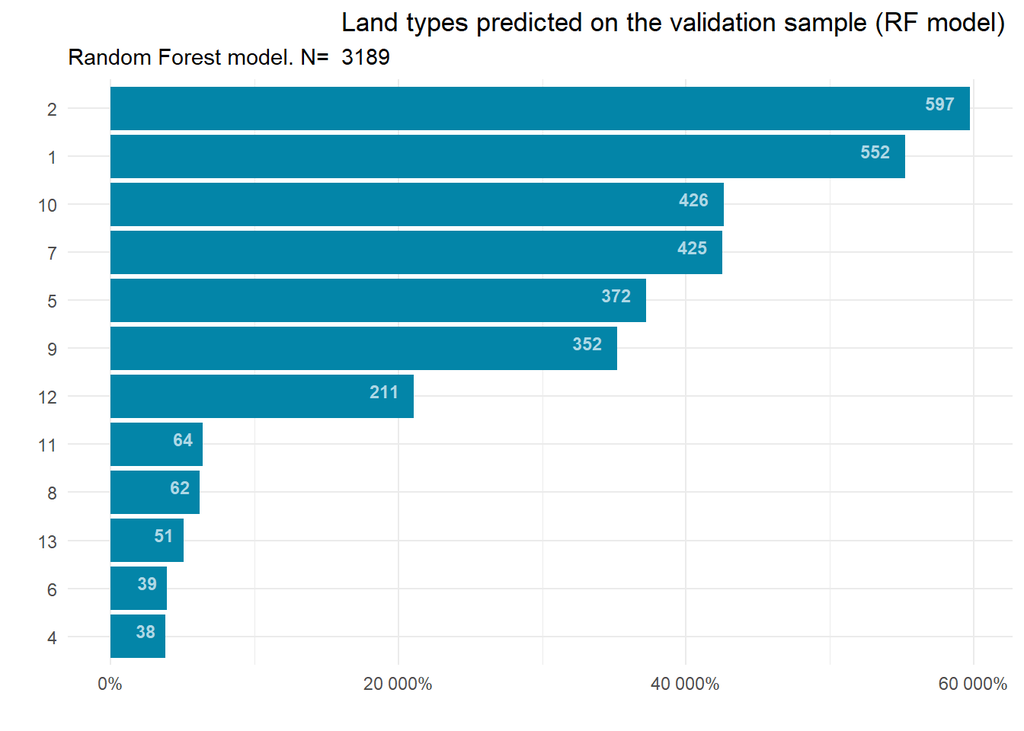

```r
ggplot(pred_classes_RF, aes(x = reorder(class, n), y = n)) +
  geom_bar(stat = "identity", fill = SIAP.color) +
   geom_text(aes(label = n),
            vjust = 0.1, hjust = +1.5,  size = 3, color= "lightblue", fontface = "bold") +
  scale_y_continuous(labels = scales::percent_format()) +
  theme_minimal() +
  coord_flip()+
  theme(plot.title = element_text(hjust = 1))+
  labs(x = "", y = "", subtitle = paste ( "Random Forest model. N= ", nrow(pred_valid)))  +
  ggtitle("Land types predicted on the validation sample (RF model) ")
```

### Visualizing the model prediction per class

It is important to visualize *where* - that is for which class - the model is predicting well, or is overpredicting or underpredicting.

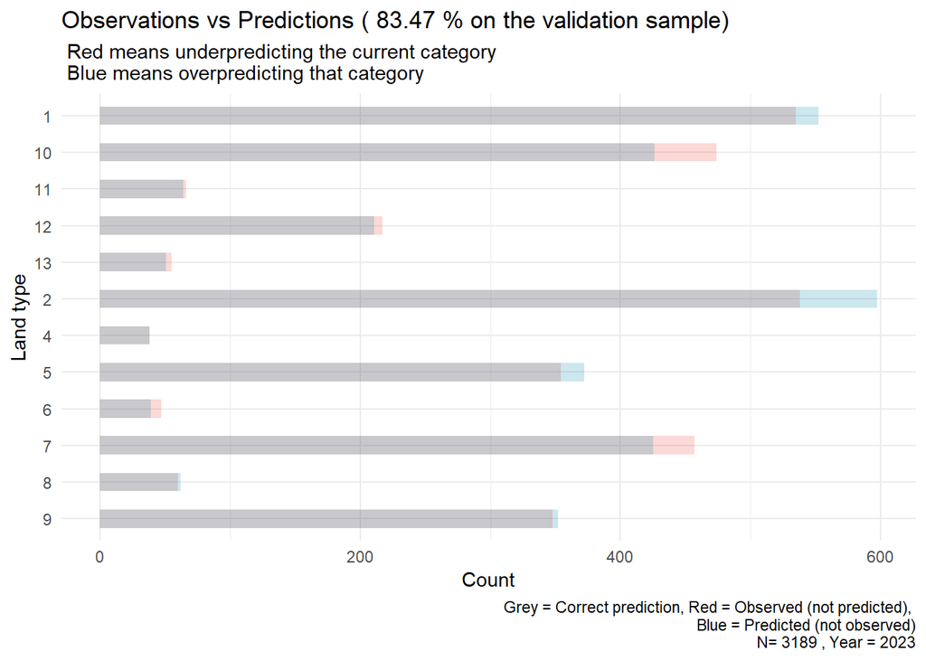

```r
# A complex to construct, but easy to read, graphic on prediction per category!
# Combine predictions and actual values
comparison <- data.frame(
  Class = validation_data$class,
  Prediction = pred_valid$rf_pred_Valid,
  Actual = validation_data$class
  )

# Reshape the data into a long format
comparison_long <- comparison %>%
  pivot_longer(
    cols = c(Actual, Prediction),         # Only include these columns
    names_to = "Type",                    # Column to distinguish "Actual" and "Prediction"
    values_to = "Category"                # Values are the category labels
  )

# Count occurrences of each category by Type
comparison_summary <- comparison_long %>%
  group_by(Category, Type) %>%
  count(name = "Count")


# Bar chart with overlays
comparison_summary %>%
mutate(Category = fct_infreq(Category) %>% fct_rev()) %>% # Reorder and reverse factor levels
ggplot()+
  aes(x = Count , y = Category, fill = Type) +
  geom_bar(stat = "identity", position = "identity", width = 0.5, alpha = 0.2) +
  scale_fill_manual(values = c("Prediction" = SIAP.color, "Actual" = SIAP.red)) +
  labs(
    title = paste("Observations vs Predictions (",outsample_accuracy, "% on the validation sample)"),
    subtitle = " Red means underpredicting the current category \n Blue means overpredicting that category",
    caption = paste("Grey = Correct prediction, Red = Observed (not predicted),
                    Blue = Predicted (not observed)\n N=", nrow(validation_data), ", Year =", StudyYear),
    y = "Land type",
    x = "Count",
    fill = "Type"
  ) +
  theme_minimal() +
  theme(legend.position = "none")
```

# Adressing the imbalance problem

## Using Kappa instead on accuracy

In the presence of imbalance classes, where one or several classes are significantly **underrepresented** compared to others, we should prefer using **kappa** instead of **accuracy** to select the best model. **Kappa** is similar to the classic accuracy measure, but it is able to take into consideration the data sets class imbalance. The definition is:

$$\kappa =
\frac{p_o-p_e}{1-p_e}$$

where $p_o$ is the accuracy of the model, and $p_e$ is the measure of the agreement between the model predictions and the actual class values as if happening by chance.[^1] The *Kappa* value indicates how much better the model is performing compared to a different model that makes random classifications based on the distribution of the target variable.

For binary classification **Kappa** can be rewritten as an expression of True Positives (TP), False Negatives (FN), False Negatives (FN), and False Positives (FP):

$$\kappa = \frac{2(TP \cdot TN - FN \cdot
FP)}{(TP + FP) \cdot (FP + TN)+ (TP+FN) \cdot (FN + TN)}$$

## Resampling techniques

There are several methods for handling imbalanced classes in a multivariate (multi-class) classification problem. Using the `caret` package, we can use several resampling techniques:

- up-sampling,
- down-sampling, and
- SMOTE

The idea is always to resample to have a more balance sample with almost the same number of observation in each class and avoid over-predicting the dominant class. We can combine this with the choice of Kappa as the metric to select the “best” model.

### Up and down sampling

Both up-sampling and down-sampling are techniques that change the distribution of the classes by removing or duplicating observations. To do that, one randomly duplicate observations or remove some

- **Up**: increase the number of instances in the minority class (less frequent class) by randomly **duplicating** observations from the minority class or by generating synthetic examples using techniques like SMOTE (see below).
- **Down**: decrease the number of instances in the majority class (most frequent class) by randomly **removing** observations from the majority class until the class distribution is balanced with the minority class.

> Up-sampling increases the size of the dataset, while down-sampling decreases it.

```r
# Remember the set of parameters we were using
# We just need to change one parameter there
K5_CV_seed_up <- trainControl(method = "cv",
                           number = K,
                           sampling = "up",   ## <-- Adding this will change the sampling distribution
                           classProbs = FALSE,
                           savePredictions = TRUE,
                           seeds = rcvSeeds,
                           allowParallel = TRUE)

# Training the up model
rf_fit_up <- train(formula,
                data = train_data,
                method = "rf",
                ntree = 100,
                metric= "Kappa", # Better for imbalance
                trControl = K5_CV_seed_up)

rf_fit_up
```

```r
K5_CV_seed_down <- trainControl(method = "cv",
                           number = K,
                           sampling = "down",   ## <-- Adding this will change the sampling distribution
                           classProbs = FALSE,
                           savePredictions = TRUE,
                           seeds = rcvSeeds,
                           allowParallel = TRUE)


rf_fit_down <- train(formula,
                data = train_data,
                method = "rf",
                ntree = 100,
                metric= "Kappa",
                trControl = K5_CV_seed_down)

rf_fit_down
```

## SMOTE (Synthetic Minority Over-sampling Technique)

In that technique, one create a new training sample from the original one. SMOTE works by generating new **synthetic** examples that are close in the feature space (some twins). For each minority class example selected, SMOTE finds its k-nearest neighbors in the feature space (typically Euclidean distance is used). It then creates new examples by choosing one of the k-nearest neighbors randomly and using it to create a new synthetic instance at a randomly selected point between the chosen neighbor and the original example. By increasing the number of minority class samples, SMOTE helps to balance the class distribution and improve the performance of machine learning models in predicting the minority class.

> SMOTE changes the training data set, we will have a **much larger** data set for training our model. It means it is likely that the model overperforms when assessing its performance *in-sample*! We have to be cautious in interpreting *in-sample* accuracies as the models use very different data sets.

```r
library(smotefamily)

# Apply SMOTE to the training data
train_sub<- train_data%>% select(-contains(c("class", "Id")))
smote_data <- SMOTE(train_sub, train_data$class, K = 5, dup_size = 0)

# Convert the oversampled data into a proper data frame
train_data_smote <- as.data.frame(smote_data$data)
train_data_smote$class <- as.factor(train_data_smote$class)

# Here we use the same parameters as for our RF model
# Should also try with different parameters
rf_fit_smote <- train(formula,
                data =  train_data_smote,
                method = "rf",
                ntree = ntree_best,  # Selecting the same as for initial RF
                metric= "Kappa",
                trControl = K5_CV_seed)

rf_fit_smote
```

## Comparing all models

All these models use different parameters and have specific advantages and drawbacks. We may still want to compare their **predictive performances** on the various measures of fit. For that we will plot the distribution of the values of these indicators on all the validation samples, for each model.[^2]

### Comparing bases on accuracy- In Sample

It is important to compare models base on one of the “metrics” available. In our case, we will focus on “Accuracy” or “Kappa” as these are the most relevant. But one may as well be focusing on one particular class specificity if there is one class that one wish to predict well.

```r
models <- list( RF =rf_final_fit,
                RF_up = rf_fit_up,
                RF_down = rf_fit_down,
                RF_Smote =  rf_fit_smote)

perf <- resamples(models)

colvec <- c('#fbb4ae','#ccebc5','#decbe4','#fed9a6','#ffffcc')
```

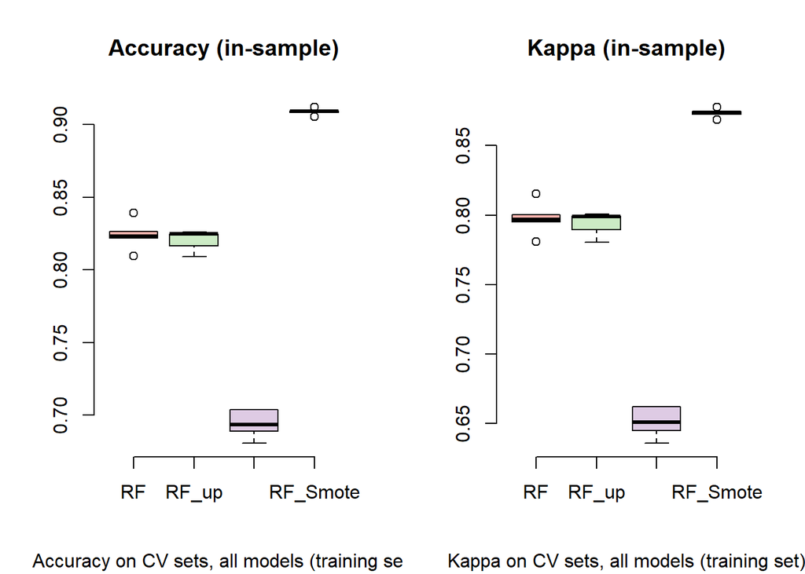

```r
par(mfrow = c(1, 2))
# Comparing models based on Accuracy
boxplot(perf$values[c("RF~Accuracy",
                      "RF_up~Accuracy", "RF_down~Accuracy", "RF_Smote~Accuracy")],
        names = names(models), col=colvec,
        main = "Accuracy (in-sample)",
        sub = "Accuracy on CV sets, all models (training set)",
        frame.plot = FALSE)

# Comparing models based on Kappa
boxplot(perf$values[c("RF~Kappa",
                      "RF_up~Kappa", "RF_down~Kappa", "RF_Smote~Kappa")],
        names = names(models), col=colvec,
        main= "Kappa (in-sample)",
        sub = "Kappa on CV sets, all models (training set)",
        frame.plot = FALSE)
```

> Depending on the criterion choosed and on the objective of the prediction, on may prefer one model to another.

## Comparing predictions on the validation set: Out-of-sample

```r
smote_pred_Valid <- predict(rf_fit_smote, validation_data)
smote_CM <- confusionMatrix(smote_pred_Valid, validation_data$class)
```

```r
# Out-of-sample accuracy
smote_outsample_accuracy <- round(100*smote_CM$overall[1], 2)
```

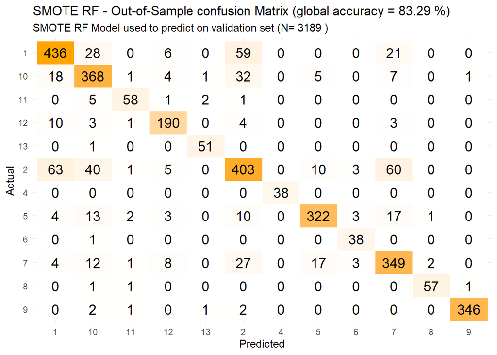

```r
# SMOTE CM
# Convert the confusion matrix to a data frame
smote_cm_df <- as.data.frame(smote_CM$table)
# Plot with reversed Y-axis and added total column
smote_cm_df %>%
  ggplot(aes(x = Reference, y = fct_rev(Prediction), fill = Freq)) +
  geom_tile(color = "white") +
  geom_text(aes(label = Freq), color = "black", size = 5) +
  scale_fill_gradient(low = "white", high = "orange") +
  labs(title = paste("SMOTE RF - Out-of-Sample confusion Matrix (global accuracy =",smote_outsample_accuracy, "%)"),
       subtitle = paste("SMOTE RF Model used to predict on validation set (N=",nrow(validation_data), ")"),
       x = "Predicted", y = "Actual") +
  theme_minimal()+
  theme (legend.position ="none")
```

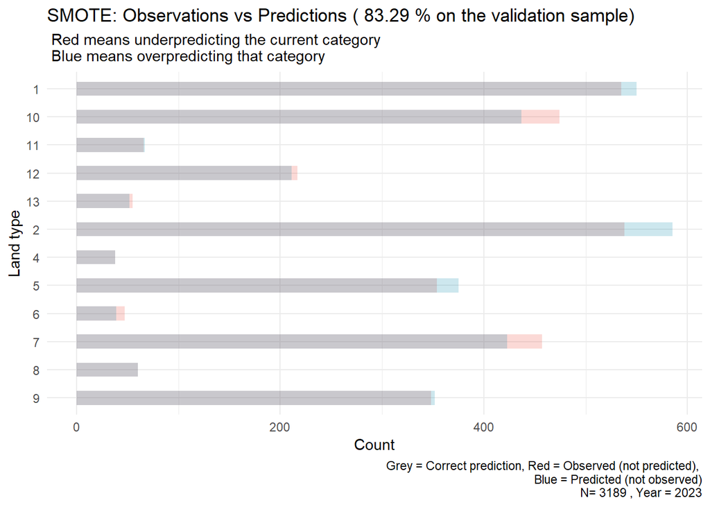

```r
# A complex to construct, but easy to read, graphic on prediction per category!
# Combine predictions and actual values

comparisonSMOTE <- data.frame(
  Class = validation_data$class,
  Prediction = smote_pred_Valid,
  Actual = validation_data$class
  )

# Reshape the data into a long format
comparisonSMOTE_long <- comparisonSMOTE %>%
  pivot_longer(
    cols = c(Actual, Prediction),         # Only include these columns
    names_to = "Type",                    # Column to distinguish "Actual" and "Prediction"
    values_to = "Category"                # Values are the category labels
  )

# Count occurrences of each category by Type
comparisonSMOTE_summary <- comparisonSMOTE_long %>%
  group_by(Category, Type) %>%
  count(name = "Count")


# Bar chart with overlays
comparisonSMOTE_summary %>%
mutate(Category = fct_infreq(Category) %>% fct_rev()) %>% # Reorder and reverse factor levels
ggplot()+
  aes(x = Count , y = Category, fill = Type) +
  geom_bar(stat = "identity", position = "identity", width = 0.5, alpha = 0.2) +
  scale_fill_manual(values = c("Prediction" = SIAP.color, "Actual" = SIAP.red)) +
  labs(
    title = paste("SMOTE: Observations vs Predictions (",smote_outsample_accuracy, "% on the validation sample)"),
    subtitle = " Red means underpredicting the current category \n Blue means overpredicting that category",
    caption = paste("Grey = Correct prediction, Red = Observed (not predicted),
                    Blue = Predicted (not observed)\n N=", nrow(validation_data), ", Year =", StudyYear),
    y = "Land type",
    x = "Count",
    fill = "Type"
  ) +
  theme_minimal()+
  theme(legend.position = "none")
```

# Predictions on the whole area

We now take the whole image and predict on **all observations = all pixels** using the model that we estimated.

## Predictions with *Random Forest*

While doing the prediction on the whole area (each pixel of the raster on the ROI), weexport the results to a *.tif* file that will be used in QGIS.

```r
# We will store the prediction in a specific folder:
dir.create(paste0("Data/",MyDir,"/Predictions_with_R",StudyYear), showWarnings = FALSE)

#  Export prediction with Random Forest model as TIFF
rf_result <- raster::predict(img, rf_final_fit, na.rm =TRUE,
                  filename = paste0("Data/",MyDir,"/Predictions_with_R",StudyYear,"/classification_fromRF.tif"),
                  overwrite = TRUE
                  )

# Create manually the classification names!
rat <- data.frame(ID =  c( 1 , 2 ,4 , 5,  6,  7,  8,  9, 10, 11, 12, 13),
                  class = as.factor(class_labels))

levels(rf_result) <- rat
# plot(rf_result, main = "Predicted Classification")
```

```r
# Extract predictions as a vector (ignoring NAs)
pred_values <- values(rf_result) %>% na.omit()

# Create a table of class proportions
prop_table <- tibble(Class = factor(pred_values)) %>%
  count(Class) %>%
  mutate(Proportion = n / sum(n)) %>%
  arrange(desc(Proportion))

levels(prop_table$Class) <- class_labels

# Print the table nicely
prop_table %>%
  knitr::kable(digits = 3, col.names = c("Class", "Count", "Proportion"))
```

[output not shown]

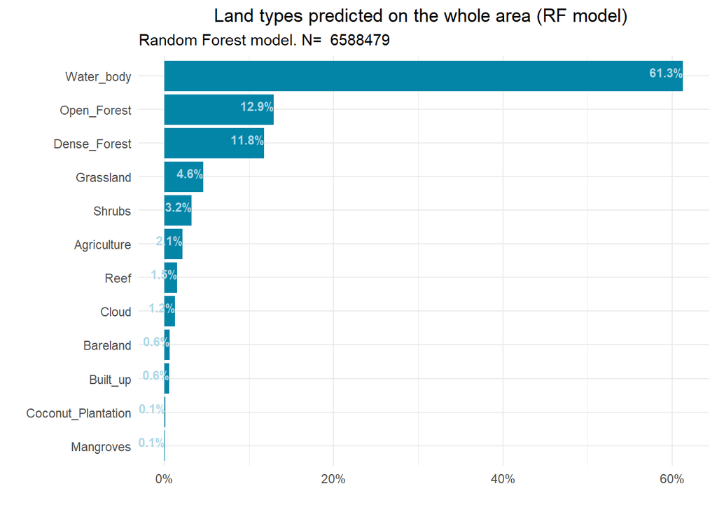

```r
ggplot(prop_table, aes(x = reorder(Class, Proportion), y = Proportion)) +
  geom_bar(stat = "identity", fill = SIAP.color) +
   geom_text(aes(label = scales::percent(Proportion, accuracy = 0.1)),
            vjust = 0.1, hjust = +1,  size = 3, color= "lightblue", fontface = "bold") +
  scale_y_continuous(labels = scales::percent_format()) +
  theme_minimal() +
  coord_flip()+
  theme(plot.title = element_text(hjust = 0.5))+
  labs(x = "", y = "", subtitle = paste ( "Random Forest model. N= ", length(pred_values)))  +
  ggtitle("Land types predicted on the whole area (RF model) ")
```